# Case study: How does a bike-share navigate speedy success?

[figure not shown]

## Introduction

Welcome to the Cyclistic bike-share analysis case study! In this case study, you work for a fictional company, Cyclistic, along with some key team members. In order to answer the business questions, follow the steps of the data analysis process: Ask, Prepare, Process, Analyze, Share, and Act. Along the way, the Case Study Roadmap tables — including guiding questions and key tasks — will help you stay on the right path.

## Scenario

You are a junior data analyst working on the marketing analyst team at Cyclistic, a bike-share company in Chicago. The director of marketing believes the company’s future success depends on maximizing the number of annual memberships. Therefore, your team wants to understand how casual riders and annual members use Cyclistic bikes differently. From these insights, your team will design a new marketing strategy to convert casual riders into annual members. But first, Cyclistic executives must approve your recommendations, so they must be backed up with compelling data insights and professional data visualizations

## Characters and teams

- **Cyclistic:** A bike-share program that features more than 5,800 bicycles and 600 docking stations. Cyclistic sets itself apart by also offering reclining bikes, hand tricycles, and cargo bikes, making bike-share more inclusive to people with disabilities and riders who can’t use a standard two-wheeled bike. The majority of riders opt for traditional bikes; about 8% of riders use the assistive options. Cyclistic users are more likely to ride for leisure, but about 30% use the bikes to commute to work each day.
- **Lily Moreno:** The director of marketing and your manager. Moreno is responsible for the development of campaigns and initiatives to promote the bike-share program. These may include email, social media, and other channels.
- **Cyclistic marketing analytics team:** A team of data analysts who are responsible for collecting, analyzing, and reporting data that helps guide Cyclistic marketing strategy. You joined this team six months ago and have been busy learning about Cyclistic’s mission and business goals—as well as how you, as a junior data analyst, can help Cyclistic achieve them.
- **Cyclistic executive team:** The notoriously detail-oriented executive team will decide whether to approve the recommended marketing program.

## About the company

In 2016, Cyclistic launched a successful bike-share offering. Since then, the program has grown to a eet of 5,824 bicycles that are geotracked and locked into a network of 692 stations across Chicago. The bikes can be unlocked from one station and returned to any other station in the system anytime.

Until now, Cyclistic’s marketing strategy relied on building general awareness and appealing to broad consumer segments. One approach that helped make these things possible was the exibility of its pricing plans: single-ride passes, full-day passes, and annual memberships. Customers who purchase single-ride or full-day passes are referred to as casual riders. Customers who purchase annual memberships are Cyclistic members.

Cyclistic’s finance analysts have concluded that annual members are much more profitable than casual riders. Although the pricing flexibility helps Cyclistic attract more customers, Moreno believes that maximizing the number of annual members will be key to future growth. Rather than creating a marketing campaign that targets all-new customers, Moreno believes there is a solid opportunity to convert casual riders into members. She notes that casual riders are already aware of the Cyclistic program and have chosen Cyclistic for their mobility needs.

Moreno has set a clear goal: Design marketing strategies aimed at converting casual riders into annual members. In order to do that, however, the team needs to beer understand how annual members and casual riders differ, why casual riders would buy a membership, and how digital media could affect their marketing tactics. Moreno and her team are interested in analyzing the Cyclistic historical bike trip data to identify trends.

## Ask

Three questions will guide the future marketing program:

1. How do annual members and casual riders use Cyclistic bikes differently?
2. Why would casual riders buy Cyclistic annual memberships?
3. How can Cyclistic use digital media to influence casual riders to become members?

Moreno has assigned you the first question to answer: How do annual members and casual riders use Cyclistic bikes differently?

You will produce a report with the following deliverables:

1. A clear statement of the business task
2. A description of all data sources used
3. Documentation of any cleaning or manipulation of data
4. A summary of your analysis
5. Supporting visualizations and key findings
6. Your top three recommendations based on your analysis

Use the following Case Study Roadmap as a guide. Note: Completing this case study within a week is a reasonable goal.

### Case Study Roadmap - Ask

**Guiding questions**

- What is the problem you are trying to solve?
- How can your insights drive business decisions?

**Key tasks**

- Identify the business task
- Consider key stakeholders

**Deliverable**

- A clear statement of the business task

——————————————————————————————————————————————

### **Case Study Roadmap: Ask Phase**

#### **Guiding Questions**

1. **What is the problem you are trying to solve?**
   - Cyclistic wants to understand how annual members and casual riders use their bike-share system differently to develop strategies that encourage casual riders to purchase annual memberships.
2. **How can your insights drive business decisions?**
   - By identifying differences in usage patterns (e.g., trip duration, peak times, preferred stations), Cyclistic can:
     - Tailor marketing campaigns targeting casual riders with specific benefits of membership.
     - Optimize operational strategies, such as bike distribution and station placement, to enhance the user experience.
     - Design membership plans or promotions that align with the needs of casual riders (e.g., flexible plans for weekend users).

#### **Key Tasks**

1. **Identify the Business Task**
   - **Business Task:** To analyze the differences in usage patterns between annual members and casual riders to inform strategies for increasing membership conversion and improving service delivery.
2. **Consider Key Stakeholders**
   - **Primary Stakeholders:**
     - **Cyclistic Marketing Team:** Needs insights to design targeted campaigns for casual riders.
     - **Cyclistic Operations Team:** Requires data to optimize bike distribution and station management.
   - **Secondary Stakeholders:**
     - **Cyclistic Leadership/Management:** Seeks to align findings with broader business goals, such as increasing profitability and market share.

#### **Deliverable**

**Business Task Statement:**  
Analyze Cyclistic bike-share usage data to uncover differences in trip patterns, station preferences, and temporal trends between annual members and casual riders. These insights will guide targeted marketing strategies to convert casual riders into members and enhance service efficiency.

——————————————————————————————————————————————

——————————————————————————————————————————————

## **Prepare**

Use Cyclistic’s historical trip data to analyze and identify trends. [Download the previous 12months of Cyclistic trip data here.](https://divvy-tripdata.s3.amazonaws.com/index.html) (Note: The datasets have a different name because Cyclistic is a fictional company. For the purposes of this case study, the datasets are appropriate and will enable you to answer the business questions. The data has been made available by Motivate International Inc. under this [license](https://www.divvybikes.com/data-license-agreement).) This is public data that you can use to explore how different customer types are using Cyclistic bikes. But note that data-privacy issues prohibit you from using riders’ personally identifiable information. This means that you won’t be able to connect pass purchases to credit card numbers to determine if casual riders live in the Cyclistic service area or if they have purchased multiple single passes.

Now, prepare your data for analysis using the following Case Study Roadmap as a guide:

### **Case Study Roadmap - Prepare**

**Guiding questions**

- Where is your data located?
- How is the data organized?
- Are there issues with bias or credibility in this data? [Does your data ROCCC?](https://www.coursera.org/learn/data-preparation/lecture/lHirM/what-is-bad-data)
- How are you addressing licensing, privacy, security, and accessibility?
- How did you verify the data’s integrity?
- How does it help you answer your question?
- Are there any problems with the data?

**Key tasks**

- Download data and store it appropriately.
- Identify how it’s organized.
- Sort and lter the data.
- Determine the credibility of the data.

**Deliverable**

- A description of all data sources used

——————————————————————————————————————————————

### **Case Study Roadmap: Prepare Phase**

#### **Guiding Questions**

1. **Where is your data located?**
   - The data is located on a publicly accessible Amazon S3 link: [Divvy Trip Data](https://divvy-tripdata.s3.amazonaws.com/index.html).
2. **How is the data organized?**
   - The data consists of CSV files, with each file containing trip data for a specific month. Key columns include:
     - `ride_id`, `rideable_type`, `started_at`, `ended_at`, `start_station_name`, `start_station_id`, `end_station_name`, `end_station_id`, `start_lat`, `start_lng`, `end_lat`, `end_lng`, and `member_casual`.
   - Data is organized with each row representing a unique trip.
3. **Are there issues with bias or credibility in this data? Does your data ROCCC (Reliable, Original, Comprehensive, Current, Cited)?**
   - **Reliability:** The data is provided by Motivate International Inc., a credible operator of bike-sharing systems.
   - **Originality:** It is first-party operational data from bike-share usage.
   - **Comprehensiveness:** Covers detailed trip metrics but lacks demographic or geographic home-location details due to privacy.
   - **Currency:** The dataset includes the last 12 months, ensuring up-to-date analysis.
   - **Citations:** Licensing and source attribution are clear.
4. **How are you addressing licensing, privacy, security, and accessibility?**
   - The data is publicly licensed under the [Divvy Bikes Data License Agreement](https://www.divvybikes.com/data-license-agreement).
   - Privacy concerns are addressed as personally identifiable information (PII) is excluded.
   - Access is unrestricted and secure via the official data link.
5. **How did you verify the data’s integrity?**
   - Ensure file completeness (all expected columns present).
   - Check for duplicate or missing entries.
   - Validate date formats and numeric ranges (e.g., coordinates, trip durations).
6. **How does it help you answer your question?**
   - This data provides insights into usage patterns, such as trip durations, times, and locations, segmented by rider type (casual vs. members), enabling direct comparisons.
7. **Are there any problems with the data?**
   - **Limitations:**
     - Lack of demographic data prevents insights into user profiles.
     - Incomplete station information in some rows may require imputation or filtering.
   - **Challenges:**
     - Outliers or incorrect data entries (e.g., negative trip durations) need cleaning.

#### **Key Tasks**

1. **Download Data and Store Appropriately**
   - Downloaded all 12 CSV files and organize them in a secure local environment.
2. **Identify Data Organization**
   - Examined column headers and ensured uniformity across files.

### **1. Examine Column Headers and Ensure Uniformity Across Files**

#### **Steps:**

     - Import all CSV files into a list.
     - Check column headers for consistency.

#### **Code:**

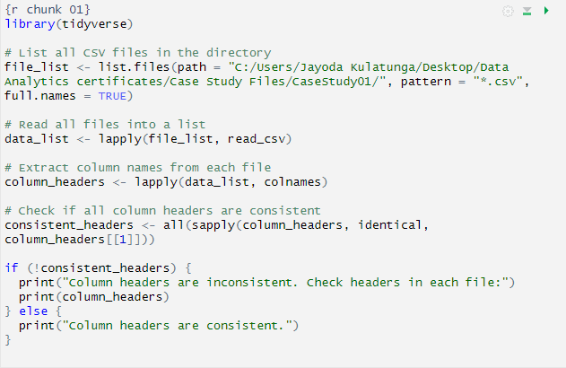

3. **Sort and Filter Data**
   - Removed duplicates and trips with incomplete data (e.g., missing station IDs).

### **2. Remove Duplicates and Trips with Incomplete Data**

#### **Steps:**

     - Combine data into one dataframe.
     - Remove duplicate rows.
     - Filter rows with missing station IDs or other critical columns.

#### **Code:**

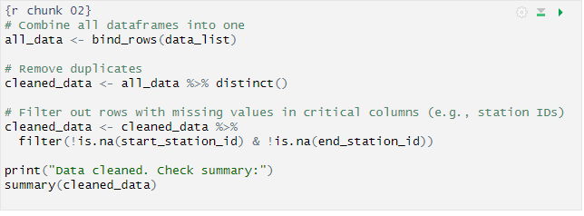

   - Filtered for realistic trip durations (e.g., exclude rides lasting 0 minutes).

### **3. Filter for Realistic Trip Durations**

#### **Steps:**

     - Calculate trip durations using `started_at` and `ended_at`.
     - Filter out rows with non-positive durations or unrealistic values.

#### **Code:**

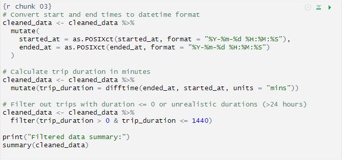

### **Final Data Export (Optional)**

   If you want to save the cleaned data:

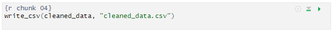

4. **Determine Credibility of Data**
   - Cross-checked metadata and file sources against the official Divvy data site to ensure authenticity.

#### **Deliverable**

**Description of Data Sources:**  
The data consists of 12 CSV files representing Cyclistic bike-share trip data from the past year. The datasets include key trip-level details such as trip duration, bike type, start/end times, start/end stations, and rider type (casual or member). The data is publicly available via an official repository maintained by Motivate International Inc. under a public license agreement.

——————————————————————————————————————————————

——————————————————————————————————————————————

## Process

Then, process your data for analysis using the following Case Study Roadmap as a guide:

### Case Study Roadmap - Process

**Guiding questions**

- What tools are you choosing and why?
- Have you ensured your data’s integrity?
- What steps have you taken to ensure that your data is clean?
- How can you verify that your data is clean and ready to analyze?
- Have you documented your cleaning process so you can review and share those results?

**Key tasks**

- Check the data for errors.
- Choose your tools.
- Transform the data so you can work with it efectively.
- Document the cleaning process.

**Deliverable**

- Documentation of any cleaning or manipulation of data

### **Follow these steps:**

1. [Download the previous 12 months of trip data.](https://divvy-tripdata.s3.amazonaws.com/index.html) **Note:** If you are planning on using Posit’s RStudio, use the [Divvy 2019 Q1](https://docs.google.com/spreadsheets/d/1uCTsHlZLm4L7-ueaSLwDg0ut3BP_V4mKDo2IMpaXrk4/template/preview?resourcekey=0-dQAUjAu2UUCsLEQQt20PDA#gid=1797029090) and [Divvy 2020](https://docs.google.com/spreadsheets/d/179QVLO_yu5BJEKFVZShsKag74ZaUYIF6FevLYzs3hRc/template/preview#gid=640449855) Q1 datasets. Choosing other data might lead to errors because the data exceeds the memory available in the free plan.
2. Unzip the files.
3. Create a folder on your desktop or Drive to house the files. Use appropriate file-naming conventions.
4. Create subfolders for the .csv file and the .xls or Sheets file so that you have a copy of the original data. Move the downloaded files to the appropriate subfolder.
5. Follow these instructions for either Excel (a) or Google Sheets (b):

   a. Launch Excel, open each file, and choose to Save As an Excel Workbook file. Put it in the subfolder you created for .xls files.
   2. Open each .csv file in Google Sheets and save it to the appropriate subfolder.
6. Open your spreadsheet and create a column called **ride_length**. Calculate the length of each ride by subtracting the column **started_at** from the column **ended_at** (for example, =D2-C2) and format as HH:MM:SS using Format > Cells > Time > 373055.
7. Create a column called **day_of_week**, and calculate the day of the week that each ride started using the **WEEKDAY** command (for example, **=WEEKDAY(C2,1)**) in each file. Format as General or as a number with no decimals, noting that 1 = Sunday and 7 = Saturday.
8. Proceed to the analyze step.

If you like, continue working with the data to beer familiarize yourself, and perhaps even identify new approaches to answering the business questions.

——————————————————————————————————————————————

### **Case Study Roadmap: Process Phase**

#### **Guiding Questions**

1. **What tools are you choosing and why?**
   - **Tool:** RStudio (Posit’s RStudio)
     - **Why:**
       - Efficient handling of large datasets.
       - Flexibility with data manipulation and cleaning using packages like `tidyverse`.
       - Reproducibility and ability to document the workflow in R scripts or RMarkdown.
2. **Have you ensured your data’s integrity?**
   - Verified data by checking for missing values, duplicates, and outliers.
   - Ensured column names and data types are consistent across all datasets.
3. **What steps have you taken to ensure that your data is clean?**
   - Checked column uniformity across files.
   - Removed duplicates and rows with missing values in key columns.
   - Filtered unrealistic ride durations (e.g., <=0 minutes or >24 hours).
4. **How can you verify that your data is clean and ready to analyze?**
   - Validate cleaned data using `summary()` and `glimpse()` functions in R.
   - Check for outliers and verify logical consistency (e.g., ride start times earlier than end times).
5. **Have you documented your cleaning process so you can review and share those results?**
   - Documented steps in an R script or RMarkdown file for transparency and reproducibility.

#### **Key Tasks**

1. **Check the Data for Errors**
   - Identified missing values, duplicates, or inconsistent data types.
   - Checked for logical errors, such as start times after end times.
2. **Choose Your Tools**
   - Used R for cleaning and analysis.
   - Organized original and processed files in separate folders for reference.
3. **Transform the Data**
   - Added calculated columns:
     - `ride_length`: Duration of each ride.
     - `day_of_week`: Day of the week each ride started.
   - Formated `ride_length` for analysis in minutes or seconds.
4. **Document the Cleaning Process**
   - Saved the R script used for cleaning.
   - Optionally, exported cleaned data to a CSV file for sharing.

### **Step-by-Step Instructions in R**

#### **Setup and Import Files**

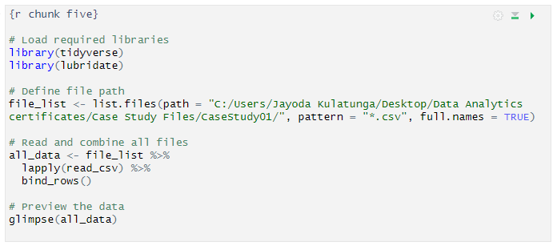

#### **Data Cleaning**

1. **Remove Duplicates and Missing Data**

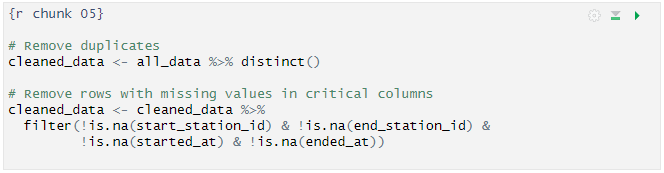

2. **Calculate Ride Length**

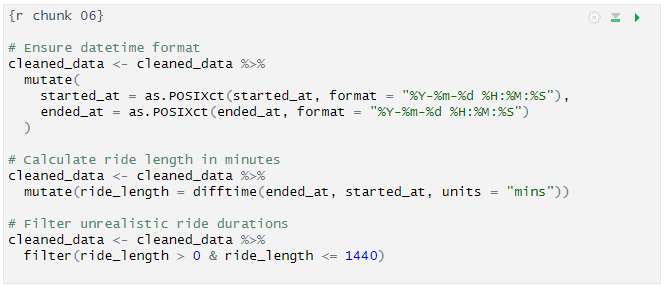

3. **Add Day of the Week**

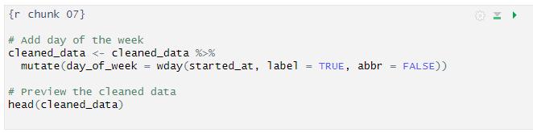

#### **Verify Cleaned Data**

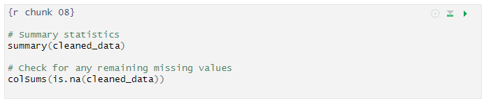

#### **Save Cleaned Data**

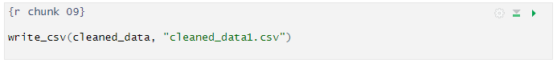

#### **Deliverable: Documentation of Cleaning Process**

——————————————————————————————————————————————

——————————————————————————————————————————————

## Analyze

Now that your data is stored appropriately and has been prepared for analysis, start puing it to work. Use the following Case Study Roadmap as a guide:

### Case Study Roadmap - Analyze

**Guiding questions**

- How should you organize your data to perform analysis on it?
- Has your data been properly formated?
- What surprises did you discover in the data?
- What trends or relationships did you find in the data?
- How will these insights help answer your business questions?

**Key tasks**

- Aggregate your data so it’s useful and accessible.
- Organize and format your data.
- Perform calculations.
- Identify trends and relationships.

**Deliverable**

- A summary of your analysis

**Follow these steps for using spreadsheets**

Open your spreadsheet application, then complete the following steps:

1. Where relevant, make columns consistent and combine them into a single worksheet.
2. Clean and transform your data to prepare for analysis.
3. Conduct descriptive analysis.
4. Run a few calculations in one file to get a beer sense of the data layout. Options:

   ● Calculate the mean of **ride_length**

   ● Calculate the max **ride_length**

   ● [Calculate the mode](https://support.google.com/docs/answer/3094029?hl=en) of **day_of_week**
5. Create a pivot table to quickly calculate and visualize the data. Options:

   ● Calculate the average **ride_length** for members and casual riders. Try rows = **member_casual**; Values = Average of **ride_length**.

   ● Calculate the average **ride_length** for users by **day_of_week**. Try columns = **day_of_week**; Rows = **member_casual**; Values = Average of **ride_length**.

   ● Calculate the number of rides for users by **day_of_week** by adding Count of trip_id to Values.
6. Open another file and perform the same descriptive analysis steps. Explore different seasons to make some initial observations.
7. Once you have spent some time working with the individual spreadsheets, merge them into a full-year view. Do this with the tool you have chosen to use to perform your nal analysis, either a spreadsheet, a database and SQL, or R Studio.
8. Export a summary file for further analysis.

**Follow these steps for using SQL** Open your SQL tool of choice, then complete the following steps:

1. Import your data.
2. Explore your data, perhaps looking at the total number of rows, distinct values, maximum, minimum, or mean values.
3. Where relevant, use JOIN statements to combine your relevant data into one table.
4. Create summary statistics.
5. Investigate interesting trends and save that information to a table.

**Follow these steps for using R** Open your preferred version of R, click [this link](https://docs.google.com/document/d/1TzCqk59_J23D5zNCvwAPSgK-5osp-wVnifsc-VOpCaI/template/preview?usp=sharing), and select “Use template.” Then, copy and paste the text from the template into an R script.

1. Import your data from [Divvy 2019 Q1](https://docs.google.com/spreadsheets/d/1uCTsHlZLm4L7-ueaSLwDg0ut3BP_V4mKDo2IMpaXrk4/template/preview?resourcekey=0-dQAUjAu2UUCsLEQQt20PDA#gid=1797029090) and [Divvy 2020 Q1](https://docs.google.com/spreadsheets/d/179QVLO_yu5BJEKFVZShsKag74ZaUYIF6FevLYzs3hRc/template/preview#gid=640449855).
2. Make columns consistent and merge them into a single dataframe.
3. Clean up and add data to prepare for analysis.
4. Conduct descriptive analysis.
5. Export a summary file for further analysis.

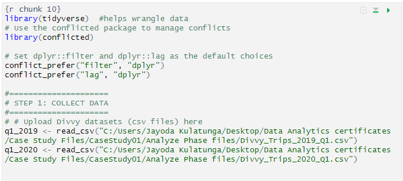

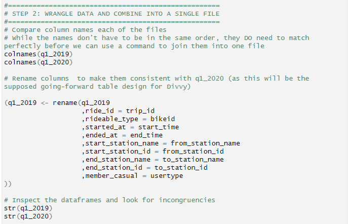

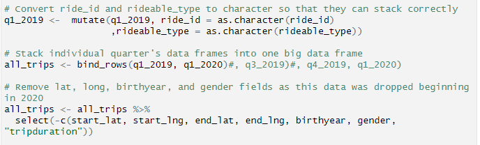

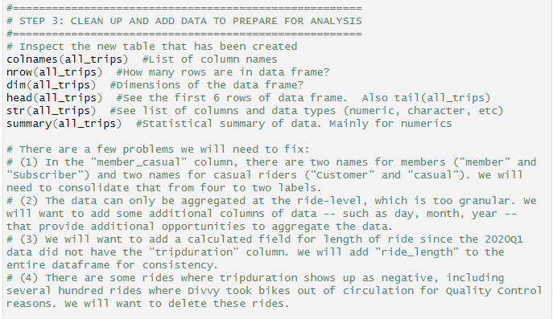

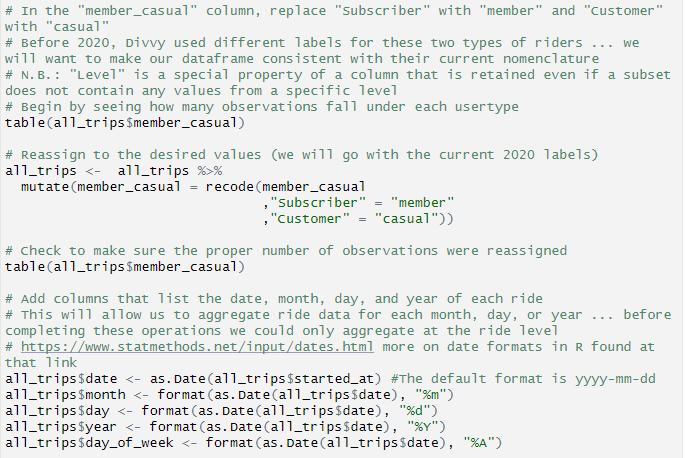

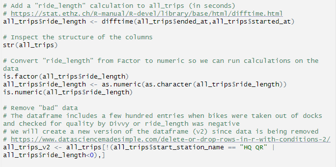

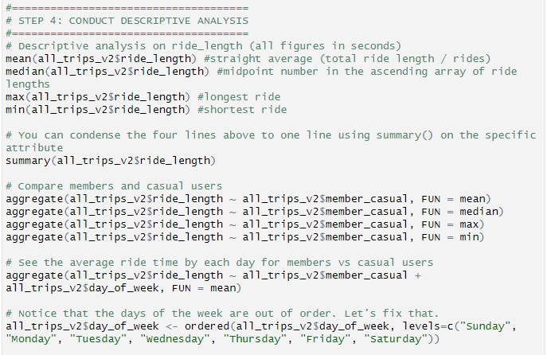

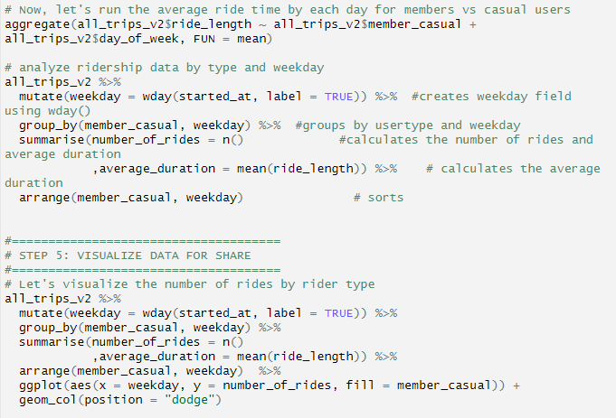

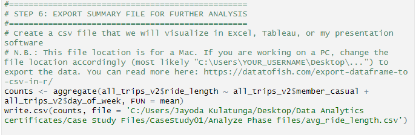

——————————————————————————————————————————————

### **Case Study Roadmap: Analyze Phase**

#### **Guiding Questions**

1. **How should you organize your data to perform analysis on it?**
   - Use a clean, single dataframe with consistent column names.
   - Aggregate and group the data by key variables like user type, ride length, and day of the week.
2. **Has your data been properly formatted?**
   - Ensure date and time columns are in `POSIXct` format.
   - Verify that categorical variables are in factors or character format.
3. **What surprises did you discover in the data?**
   - Explore anomalies such as unusually long or short rides.
   - Check user patterns that deviate from expected behavior (e.g., casual riders using bikes more during weekdays).
4. **What trends or relationships did you find in the data?**
   - Investigate differences in average ride lengths and popular riding days between members and casual riders.
5. **How will these insights help answer your business questions?**
   - Insights will reveal usage patterns that can guide marketing and operational strategies.

#### **Key Tasks**

1. **Aggregate Data**
   - Group data by `member_casual` and other key variables to compute metrics like average ride length.
2. **Organize and Format Data**
   - Ensure all variables are tidy and appropriate for visualization and statistical analysis.
3. **Perform Calculations**
   - Calculate metrics like average ride length, total rides per day, and usage by time of day.
4. **Identify Trends and Relationships**
   - Compare metrics between annual members and casual riders to highlight differences in behavior.

#### **Summary of Analysis (Deliverable)**

——————————————————————————————————————————————

——————————————————————————————————————————————

## Share

Now that you have performed your analysis and gained some insights into your data, create visualizations to share your findings. Moreno has reminded you that they should be sophisticated and polished in order to effectively communicate to the executive team. Use the following Case Study Roadmap as a guide:

### Case Study Roadmap - Share

**Guiding questions**

- Were you able to answer the question of how annual members and casual riders use Cyclistic bikes differently?
- What story does your data tell?
- How do your findings relate to your original question?
- Who is your audience? What is the best way to communicate with them?
- Can data visualization help you share your findings?
- Is your presentation accessible to your audience?

**Key tasks**

- Determine the best way to share your findings.
- Create eective data visualizations.
- Present your findings.
- Ensure your work is accessible.

**Deliverable**

- Supporting visualizations and key findings

**Follow these steps:**

1. Take out a piece of paper and a pen and sketch some ideas for how you will visualize the data.
2. Once you choose a visual form, open your tool of choice to create your visualization. Use a presentation soware, such as PowerPoint or Google Slides, your spreadsheet program, Tableau, or R.
3. Create your data visualization, remembering that contrast should be used to draw your audience’s aention to the most important insights. Use artistic principles including size, color, and shape.
4. Ensure clear meaning through the proper use of common elements, such as headlines, subtitles, and labels.
5. Rene your data visualization by applying deep aention to detail. ——————————————————————————————————————————————

### **Case Study Roadmap: Share Phase**

#### **Guiding Questions**

1. **Were you able to answer the question of how annual members and casual riders use Cyclistic bikes differently?**
   - **Yes.** The analysis highlighted clear differences in bike usage between annual members and casual riders, such as ride duration, frequency, and preferred days of the week.
2. **What story does your data tell?**
   - Casual riders tend to take longer rides and prefer weekends, suggesting recreational use.
   - Members use bikes more frequently during weekdays, indicating use for commuting or routine trips.
3. **How do your findings relate to your original question?**
   - The data aligns with the business question by illustrating the behavioral patterns of both rider types. These patterns can guide targeted marketing and operational strategies.
4. **Who is your audience? What is the best way to communicate with them?**
   - **Audience:** Cyclistic’s executive team, including Moreno.
   - **Best Communication Method:** A concise presentation with clear, accessible visualizations and actionable insights.
5. **Can data visualization help you share your findings?**
   - Yes. Visualizations like bar charts make it easier to compare metrics such as ride duration and frequency between casual riders and members.
6. **Is your presentation accessible to your audience?**
   - By using clear labels, proper colors, and avoiding excessive jargon, the presentation will be accessible to all stakeholders.

#### **Key Tasks**

1. **Determine the Best Way to Share Your Findings**
   - Create a slide deck or a report summarizing insights with supporting charts.
   - Use visuals to highlight key differences and trends.
2. **Create Effective Data Visualizations**
   - Include the provided charts:
     - **Average Ride Duration by Day of the Week** (Image 1): Shows longer rides for casual riders.

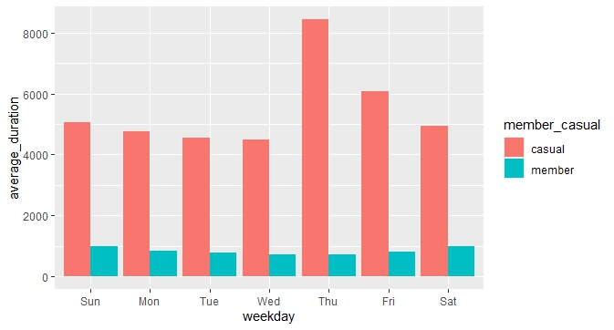

     - **Number of Rides by Rider Type** (Image 2): Highlights higher member usage on weekdays.

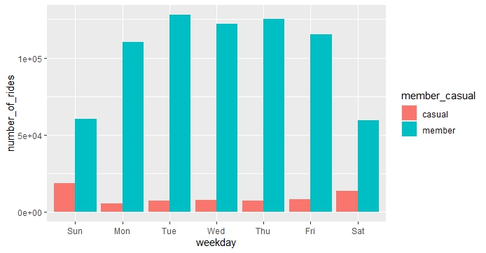

3. **Present Your Findings**
   - Start with the business question.
   - Present key insights and trends.
   - Suggest actionable recommendations.
4. **Ensure Accessibility**
   - Use descriptive titles and captions for charts.
   - Share the presentation in formats accessible to all team members (e.g., PDF and online slides).

#### **Deliverable: Supporting Visualizations and Key Findings**

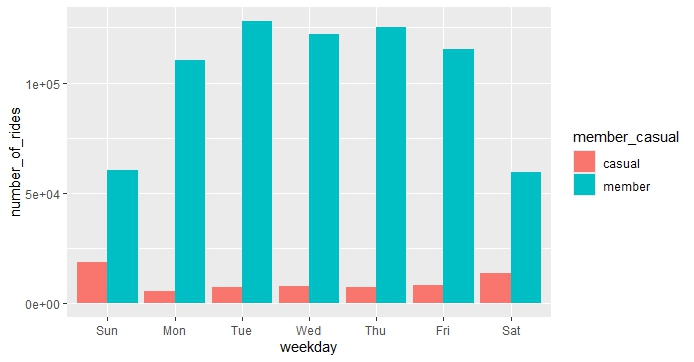

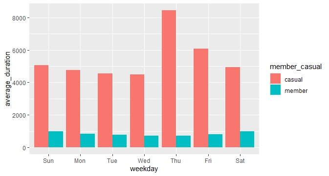

##### **Key Findings:**

- **Casual Riders:**
  - Longer average ride durations.
  - Prefer riding on weekends.
- **Annual Members:**
  - Shorter, more frequent rides.
  - Use bikes consistently on weekdays.

##### **Recommendations for Cyclistic:**

1. **Target casual riders:**
   - Weekend promotions to convert them into annual members.
2. **Enhance member benefits:**
   - Highlight weekday commuting benefits to retain members.
3. **Optimize station locations:**
   - Place more bikes in recreational areas for casual riders and near transit hubs for members.

——————————————————————————————————————————————

——————————————————————————————————————————————

## Act

Now that you have finished creating your visualizations, act on your findings. Prepare the deliverables Morena asked you to create, including the three top recommendations based on your analysis. Use the following Case Study Roadmap as a guide:

### Case Study Roadmap - Act

**Guiding questions**

- What is your final conclusion based on your analysis?
- How could your team and business apply your insights?
- What next steps would you or your stakeholders take based on your findings?
- Is there additional data you could use to expand on your findings?

**Key tasks**

- Create your portfolio.
- Add your case study.
- Practice presenting your case study to a friend or family member.

**Deliverable**

- Your top three recommendations based on your analysis

**Follow these steps:**

1. If you do not have one already, create an online portfolio.
2. Consider how you want to feature your case study in your portfolio.
3. Upload or link your case study findings to your portfolio.
4. Write a brief paragraph describing the case study, your process, and your discoveries.
5. Add the paragraph to introduce your case study in your portfolio.

——————————————————————————————————————————————

### **Next Steps**

1. Share the findings and recommendations with the marketing and operations teams.
2. Develop and test targeted campaigns, such as a pilot weekend membership program.
3. Monitor the impact of changes on ride patterns and membership sign-ups to refine strategies.

### **Additional Data to Expand Analysis**

To further refine insights and strategies, it would be useful to:

1. Incorporate demographic data (e.g., age, gender) to identify specific sub-groups among casual riders.
2. Analyze weather patterns to see how they influence ride behavior.
3. Investigate geographic trends (start and end locations) to optimize station placement.

### **Action Plan**

1. **Portfolio Creation**: Add this case study, including visualizations and insights, to your professional portfolio.
2. **Presentation Practice**: Prepare and rehearse presenting your case study with a focus on clarity and actionable insights. Use the provided visualizations to make your case compelling.
3. **Feedback Loop**: Share your recommendations with peers or mentors to gather feedback and refine your approach before presenting to stakeholders.

——————————————————————————————————————————————

——————————————————————————————————————————————

## Wrap-up

Congratulations on nishing the Cyclistic bike-share case study! If you like, complete another case study to continue growing your portfolio. Or, use the steps from the Ask, Prepare, Process, Analyze, Share, and Act Case Study Roadmap to create a new project that’s all your own. Best of luck on your job search!